# Week 7: Decision Boundary

Di Wu

03/02/2023

```r
knitr::opts_chunk$set(echo = TRUE, error = FALSE, message = FALSE, warning = FALSE)
```

```r
library(caret)
library(ISLR)
library(MASS)
library(ggplot2)
library(ggfortify)
library(GGally)
library(class)
library(dplyr)
```

# Define `boundary` Function for Decision Boundaries

The following function adds the decision boundary by evaluating the classifier at evenly spaced grid points. Note that low resolution (to make evaluation faster) will make the decision boundary look like it has small steps even if it is a (straight) line. Please do not modify the function, and use it directly in your assignment as a function.

```r
# input:
# model: classification model
# data: training set
# class: response variable

boundary <- function(model, data, class = NULL, predict_type = "class",
  resolution = 100, showgrid = TRUE, ...) {

  if(!is.null(class)) cl <- data[,class] else cl <- 1
  data <- data[,1:2]
  k <- length(unique(cl))

  plot(data, col = as.integer(cl)+1L, pch = as.integer(cl)+1L, ...)

  # make grid
  r <- sapply(data, range, na.rm = TRUE)
  xs <- seq(r[1,1], r[2,1], length.out = resolution)
  ys <- seq(r[1,2], r[2,2], length.out = resolution)
  g <- cbind(rep(xs, each=resolution), rep(ys, time = resolution))
  colnames(g) <- colnames(r)
  g <- as.data.frame(g)

  ### guess how to get class labels from predict
  ### (unfortunately not very consistent between models)
  p <- predict(model, g, type = predict_type)
  if(is.list(p)) p <- p$class
  p <- as.factor(p)

  if(showgrid) points(g, col = as.integer(p)+1L, pch = ".")

  z <- matrix(as.integer(p), nrow = resolution, byrow = TRUE)
  contour(xs, ys, z, add = TRUE, drawlabels = FALSE,
    lwd = 2, levels = (1:(k-1))+.5)

  invisible(z)
}
```

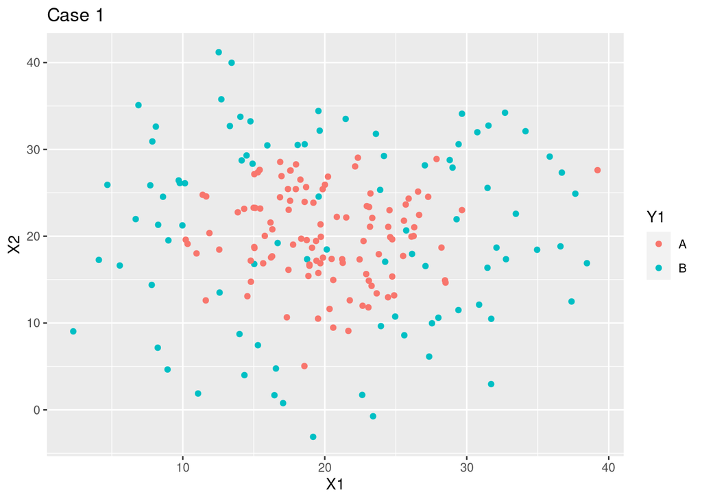

```r
# generate data set
set.seed(1)
X1 <- rnorm(200,20,8)
X2 <- rnorm(200,20,8)
Y1 <- as.factor(ifelse((X1-20)^2+(X2-20)^2<10^2, "A","B"))
Y1[sample(200, 40)] <-  as.factor(ifelse(Y1=="B", "A","B"))
Y2 <- as.factor(ifelse((X1<20 & X2 > 20) | (X1>20 & X2<20), "A","B"))
Y2[sample(200, 40)] <-  as.factor(ifelse(Y2=="B", "A","B"))
data <- data.frame(X1=X1, X2 = X2, Y1 = Y1, Y2=Y2)
# two predictors: X1, X2
# Binary response: Y1, Y2

ggplot(data) + geom_point(aes(x = X1, y = X2, color = Y1)) + ggtitle("Case 1")
```

The Y1 for A is most distributed in the center of the graph which is 10<X1<30 and 10<X2<30. The Y1 for B is most distributed outside the center of the graph which is (X1<10 or X1>30) and (X2<10 or X2>30)

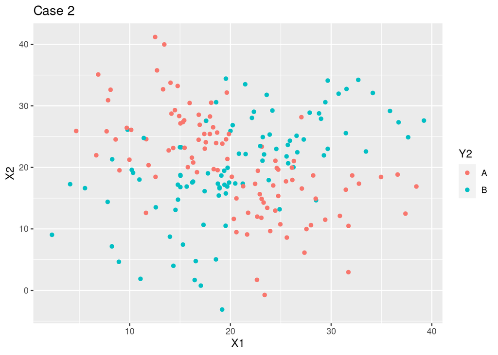

```r
ggplot(data) + geom_point(aes(x = X1, y = X2, color = Y2)) + ggtitle("Case 2")
```

```r
# creating training data as 70% of the dataset
random_sample <- createDataPartition(data$Y1,
                                p = 0.7, list = FALSE)

# generating training dataset
# from the random_sample
train_r <- data[random_sample, ]
train_rx <- train_r[,-3:-4]
train_ry <- train_r[,3:4]
# generating testing dataset
# from rows which are not
# included in random_sample
# the test_rx set have independent variables only
# the test_ry set have dependent variable only

test_rx <- data[-random_sample, -c(3,4)]

test_ry <- data[-random_sample, 3:4]
test <- cbind(test_rx, test_ry)
#train_rx[,1] <- scale(train_rx[,1])
#train_rx[,2] <- scale(train_rx[,2])
```

Since X1 and X2 are within the small range and the sample is relatively small, there is no need to scale

## Logistic Regression

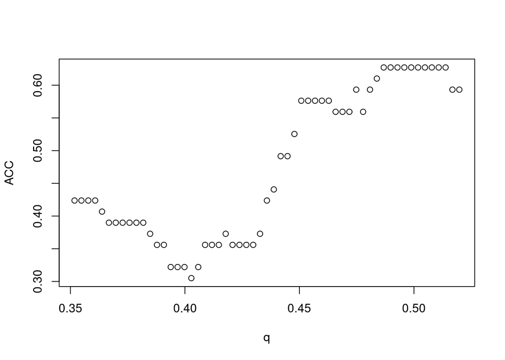

```r
# Y1 logistic model
logit.model1 <- glm(Y1 ~., train_r[,-4], family=binomial(link='logit'))


glm.prob1= predict(logit.model1, test_rx, type = "response")

ACC <- c()
# for each K=i, find the prediction,
# calculate the misclassification, store it in the ith item of vector test_misclassification


q <- seq(min(glm.prob1)+0.003,max(glm.prob1)-0.003,0.003) # generate sequence with the break 0.1

for(i in 1:length(q)){

  predicted1 <- ifelse(glm.prob1>q[i], 1, 0)
  ConMat <- table(test_ry[,-2],predicted1)
  TN <- ConMat[1,1]
  FP <- ConMat[1,2]
  FN <- ConMat[2,1]
  TP <- ConMat[2,2]
  ACC[i] <-(TP+TN)/sum(ConMat)
}
plot(q,ACC)
```

```r
q[which.max(ACC)]
```

```
## [1] 0.4868013
```

```r
max(ACC)
```

```
## [1] 0.6271186
```

```r
pred2 <- factor(ifelse(glm.prob1 > q[which.max(ACC)], 1, 0))
```

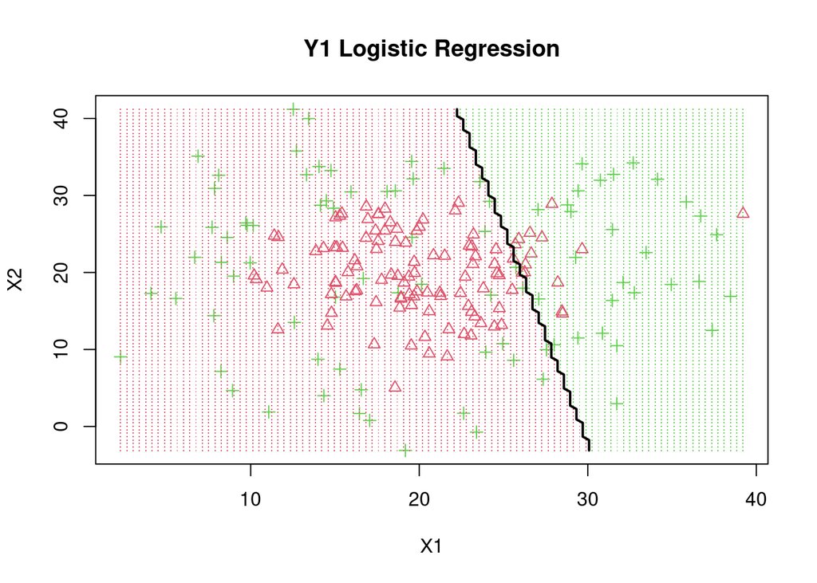

```r
# specify the cutoff point for prediction
# I didn't tune the cutoff point and just use default value 0.5 as an example
# if you need to change the cutoff point, change 0.5 to your optimal q
class(logit.model1) <- c("lr", class(logit.model1))
predict.lr <- function(object, newdata, ...)predict.glm(object, newdata, type = "response") > 0.478

boundary(logit.model1, data[,-4], class = "Y1", main = "Y1 Logistic Regression")
```

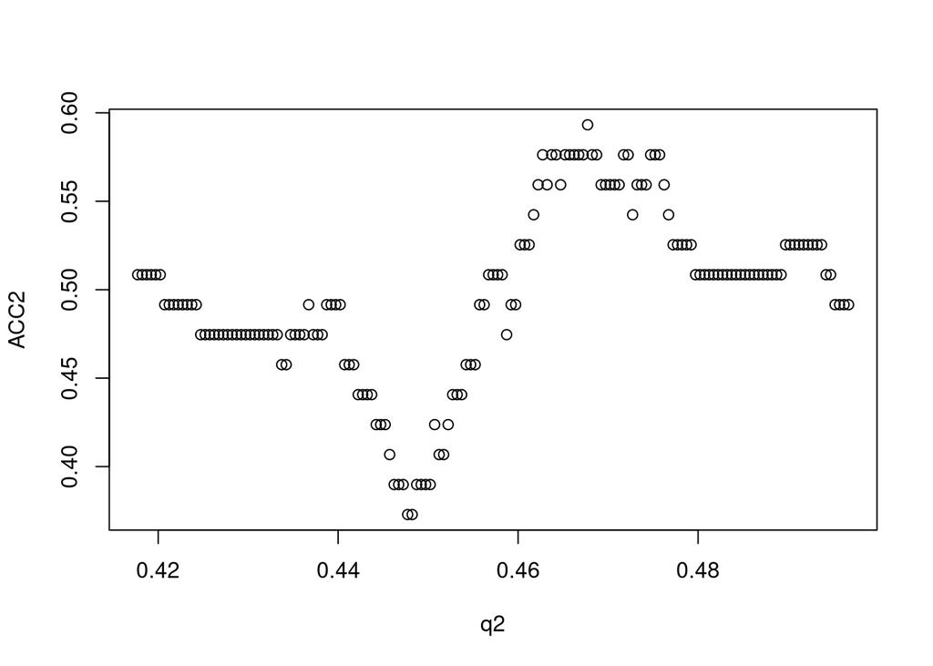

```r
# Y2 logistic model
logit.model2 <- glm(Y2 ~., train_r[,-3], family=binomial(link='logit'))


glm.prob2= predict(logit.model2, test_rx, type = "response")

ACC2 <- c()

q2 <- seq(min(glm.prob2)+0.0005,max(glm.prob2)-0.0005,0.0005) # generate sequence with the break 0.0005

for(i in 1:length(q2)){

  predicted2 <- ifelse(glm.prob2>q2[i], 1, 0)
  ConMat2 <- table(test_ry[,-1],predicted2)
  TN <- ConMat2[1,1]
  FP <- ConMat2[1,2]
  FN <- ConMat2[2,1]
  TP <- ConMat2[2,2]
  ACC2[i] <-(TP+TN)/sum(ConMat)
}
plot(q2,ACC2)
```

```r
q2[which.max(ACC2)]
```

```
## [1] 0.4677272
```

```r
max(ACC2)
```

```
## [1] 0.5932203
```

```r
pred2 <- factor(ifelse(glm.prob2 > q2[which.max(ACC2)], 1, 0))
```

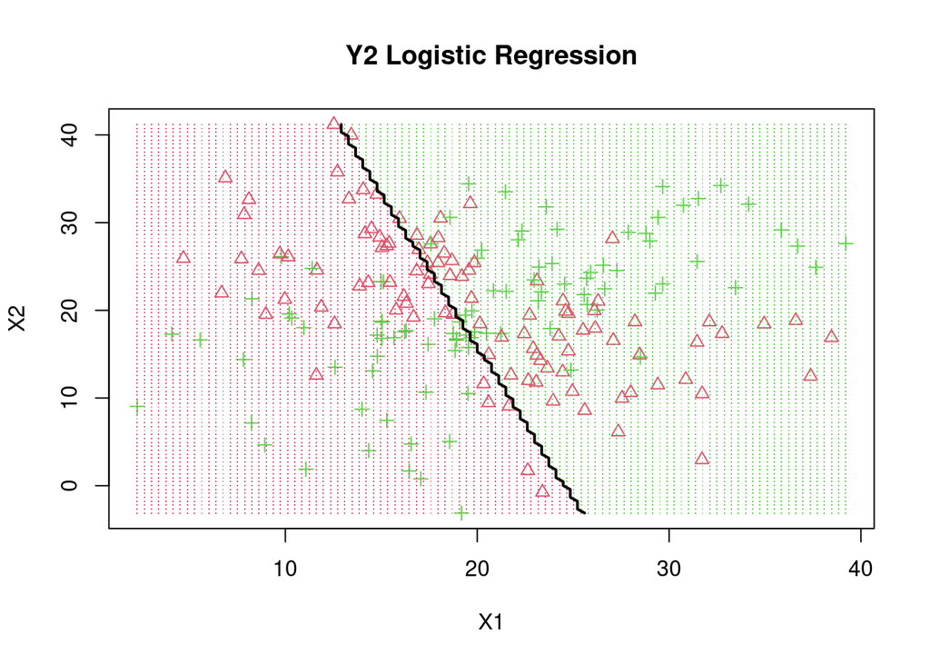

```r
class(logit.model2) <- c("lr", class(logit.model2))
predict.lr <- function(object, newdata, ...)predict.glm(object, newdata, type = "response") > 0.456

boundary(logit.model2, data[,-3], class = "Y2", main = "Y2 Logistic Regression")
```

## KNN

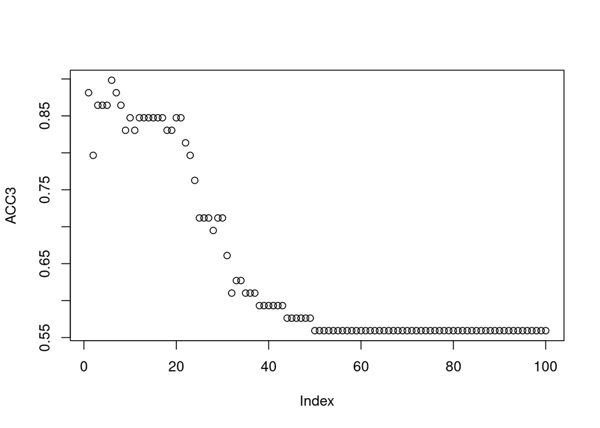

```r
# Y1
ACC3 <- c()
for(i in 1:100){
  predicted3 <- knn(train_rx,test_rx,train_ry[,-2],k=i)
  ConMat <- table(test_ry[,-2],predicted3)
  TN <- ConMat[1,1]
  FP <- ConMat[1,2]
  FN <- ConMat[2,1]
  TP <- ConMat[2,2]
  ACC3[i] <- (TP+TN)/sum(ConMat)
}
plot(ACC3)
```

```r
which.max(ACC3)
```

```
## [1] 6
```

```r
max(ACC3)
```

```
## [1] 0.8983051
```

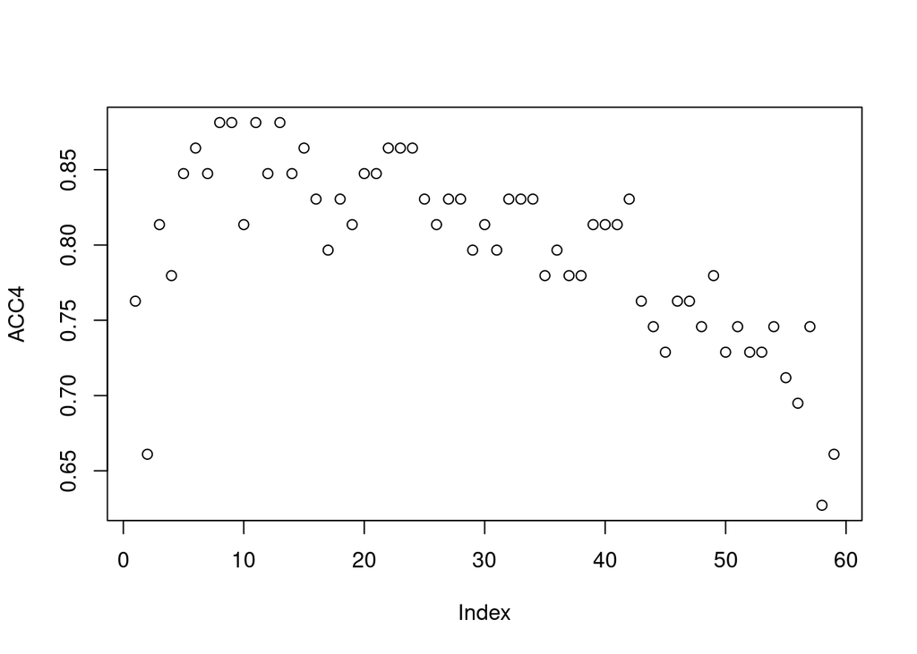

```r
# Y2
ACC4 <- c()
for(i in 1:59){
  predicted4 <- knn(train_rx,test_rx,train_ry[,-1],k=i)
  ConMat <- table(test_ry[,-1],predicted4)
  TN <- ConMat[1,1]
  FP <- ConMat[1,2]
  FN <- ConMat[2,1]
  TP <- ConMat[2,2]
  ACC4[i] <- (TP+TN)/sum(ConMat)
}
plot(ACC4)
```

```r
which.max(ACC4)
```

```
## [1] 8
```

```r
max(ACC4)
```

```
## [1] 0.8813559
```

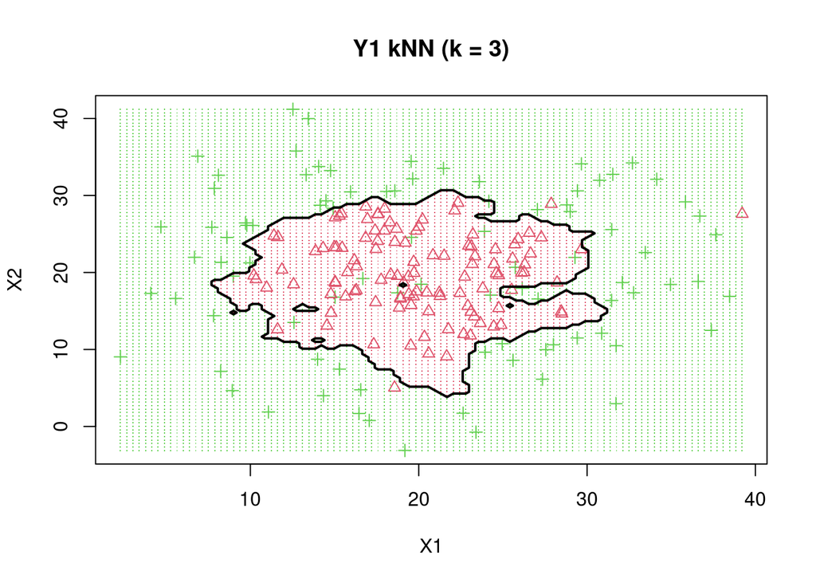

```r
# K=3
knn.model1 <- knn3(Y1 ~ ., data[,-4], k = 3)
boundary(knn.model1, data[,-4], class = "Y1", main = "Y1 kNN (k = 3)")
```

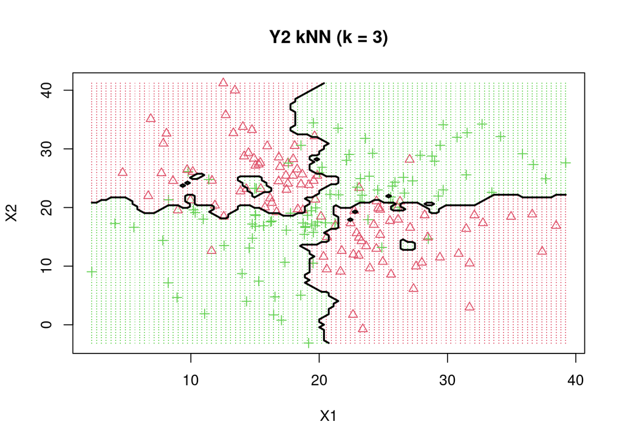

```r
# K=2
knn.model2 <- knn3(Y2 ~ ., data[,-3], k = 3)
boundary(knn.model2, data[,-3], class = "Y2", main = "Y2 kNN (k = 3)")
```

## LDA

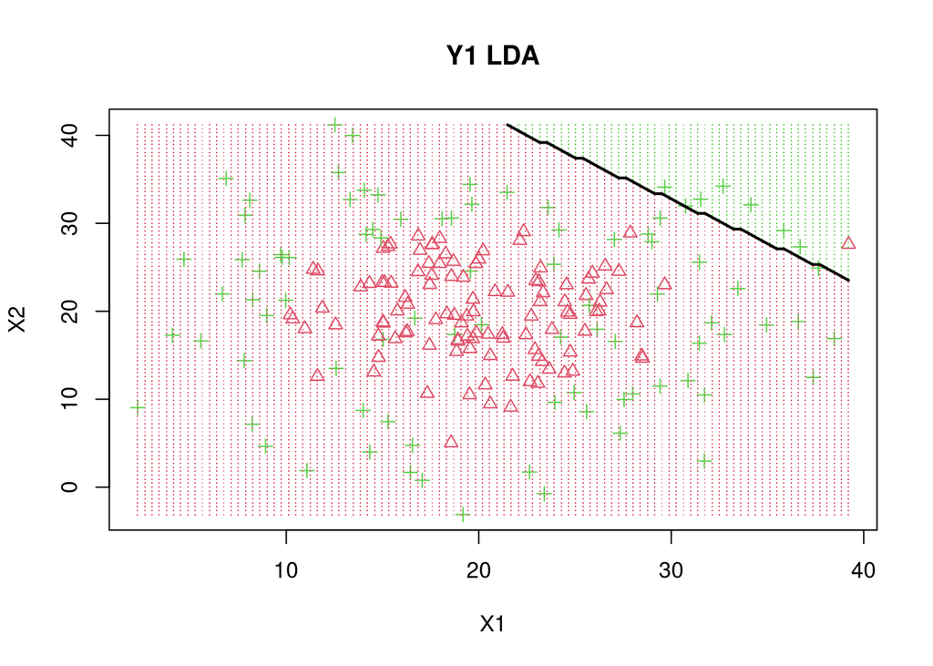

```r
# LDA: same syntax as lm
# model <- lda(y ~ x, data = data)

lda.model1 <- lda(Y1 ~ ., data[,-4])
boundary(lda.model1, data[,-4], class = "Y1", main = "Y1 LDA")
```

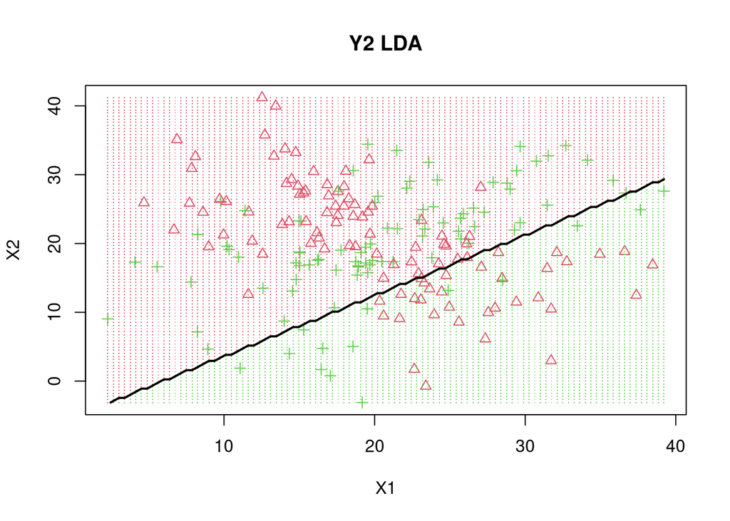

```r
lda.model2 <- lda(Y2 ~ ., data[,-3])
boundary(lda.model2, data[,-3], class = "Y2", main = "Y2 LDA")
```

There is a straight line boundary of A and B for Y1, it is more determined by X1. However, from the actual boundary known, it is not accurate and there are a lot of misclassification for green points at the left sides of the graph (the green points are classified as red at the left part of the boundary). That is the limit of the logistic regression which can only give the straight line.

There is a straight line boundary of A and B for Y2, it is determined by X1 and X2. However, from the actual boundary known, it is not accurate and there are a lot of misclassification for green points at the left sides of the graph (lots of green points are misclassified as red). That is the limit of the logistic regression which can only give the straight line.

## Decision Tree

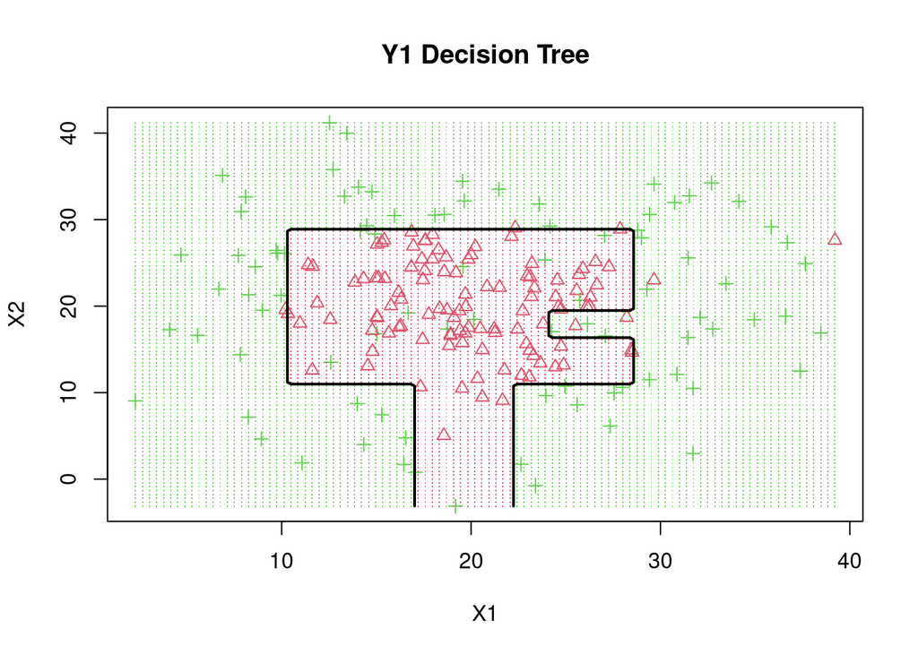

```r
library(tree)
# syntax: model <- tree(Y~X, data = data)
tree.model1 <- tree(Y1 ~ ., data[,-4])
boundary(tree.model1, data[,-4], class = "Y1", main = "Y1 Decision Tree")
```

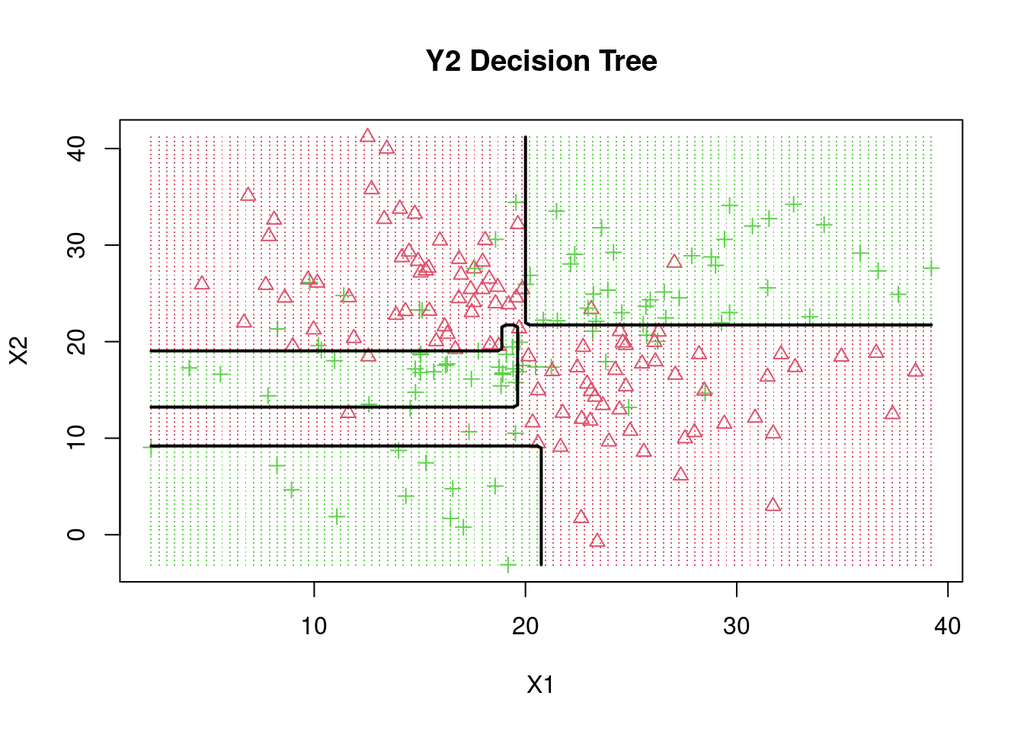

```r
tree.model2 <- tree(Y2 ~ ., data[,-3])
boundary(tree.model2, data[,-3], class = "Y2", main = "Y2 Decision Tree")
```

The boundary for the decision tree for Y1 shows the range of X1 and X2 between 10 and 30 are classfied as red points. That is almost the same as the actual boundary, when 10<X1<30 and 10<X2<30. However, it might not be accurate for X2<10 as (X2-10)^2 will be larger than 100. The boundary for Y1 is still not accurate.

## Bagging

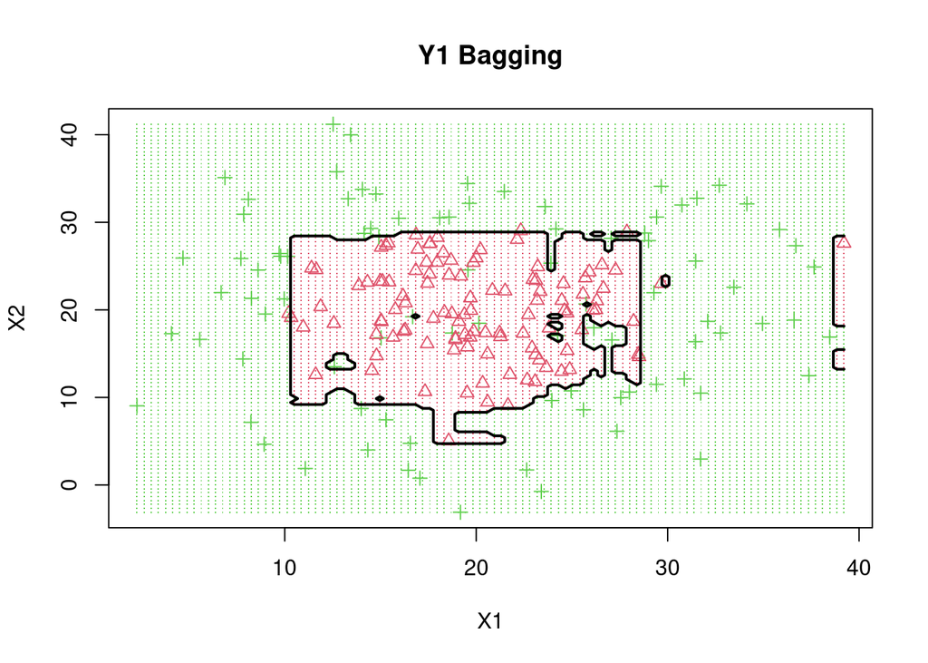

```r
library(randomForest)
# the randomForest(y~x, data) function can be used for bagging and random forest.

# Bagging is the random forest when mtry = p (the number of predictors)
# set mtry = 2 since we have two predictors

bagging.model1 <- randomForest(Y1 ~ ., data[,-4], mtry = 2, importance = TRUE)
boundary(bagging.model1, data[,-4], class = "Y1", main = "Y1 Bagging")
```

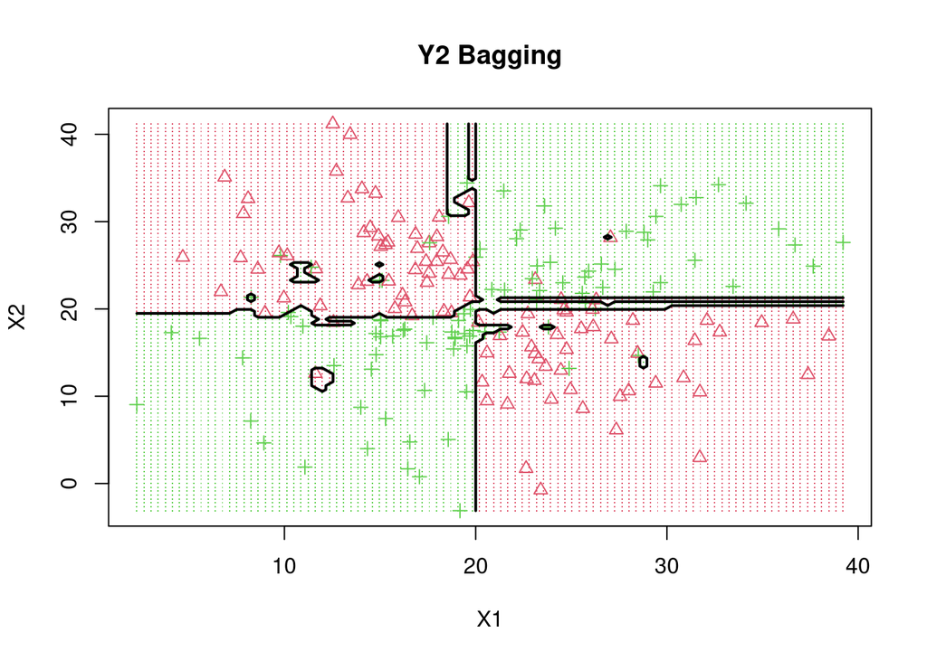

```r
bagging.model2 <- randomForest(Y2 ~ ., data[,-3], mtry = 2, importance = TRUE)
boundary(bagging.model2, data[,-3], class = "Y2", main = "Y2 Bagging")
```

The bagging for Y1 identifies every red points even with some outliers.The overall shape of the boundary is about 10<X1<30 and 10<X2<30 as well as the most right part for red points. It is almost consistent with actual boundary but there are still some misclassification of green points within the red points area especially when both green and red ones are overlapping.

The bagging for Y2 identifies every green points even with some outliers.The overall shape of the boundary is about (X1>20 and X2<20) or (X1<20 and X2>20). It is almost consistent with actual boundary but there are still few misclassification of green points within the red points area especially when both green and red ones are overlapping. It is quite hard to describe the actual boundary for those models with small groups of outliers.

## Random Forest

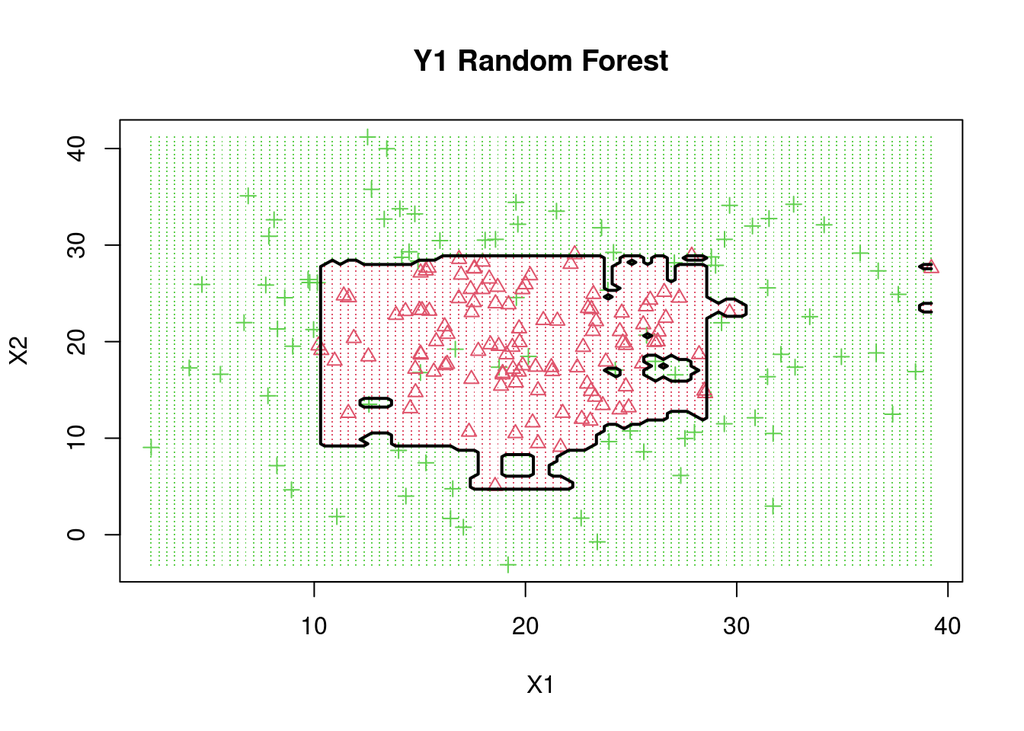

```r
library(randomForest)

# the default setting will be for random forest

rf.model1 <- randomForest(Y1 ~ ., data[,-4])
boundary(rf.model1, data[,-4], class = "Y1", main = "Y1 Random Forest")
```

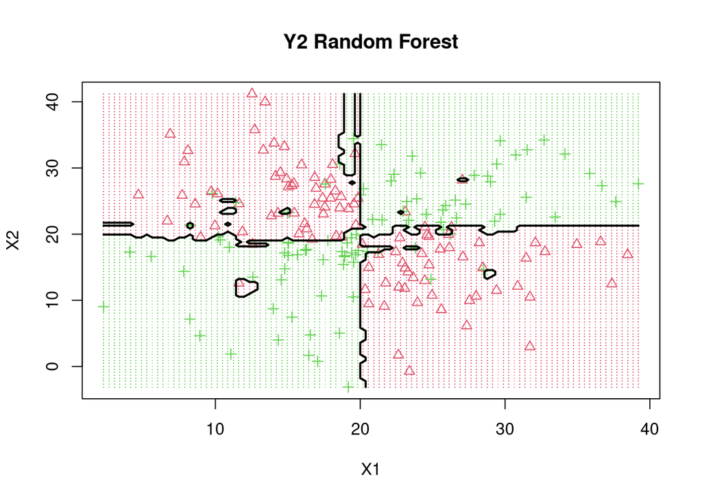

```r
rf.model2 <- randomForest(Y2 ~ ., data[,-3])
boundary(rf.model2, data[,-3], class = "Y2", main = "Y2 Random Forest")
```

The random forest for Y1 is almost the same as the bagging since there are only two classes and each time it is 50% to choose one class. It identifies every red points even with some outliers.The overall shape of the boundary is about 10<X1<30 and 10<X2<30 as well as the most right part for red points. It is almost consistent with actual boundary but there are still some misclassification of green points within the red points area especially when both green and red ones are overlapping.

The random forest for Y2 is almost the same as the bagging since there are only two classes and each time it is 50% to choose one class. It identifies every green points even with some outliers.The overall shape of the boundary is about (X1>20 and X2<20) or (X1<20 and X2>20). It is almost consistent with actual boundary but there are still few misclassification of green points within the red points area especially when both green and red ones are overlapping. It is quite hard to describe the actual boundary for those models with small groups of outliers.

## SVM

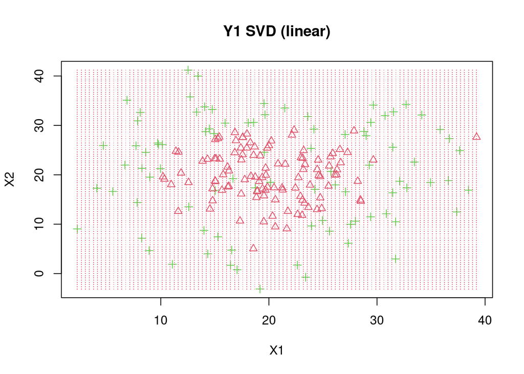

```r
library(e1071)
# Y1
# Linear Kernel
svm.model1 <- svm(Y1 ~ ., data[,-4], kernel="linear")
boundary(svm.model1, data[,-4], class = "Y1", main = "Y1 SVD (linear)")
```

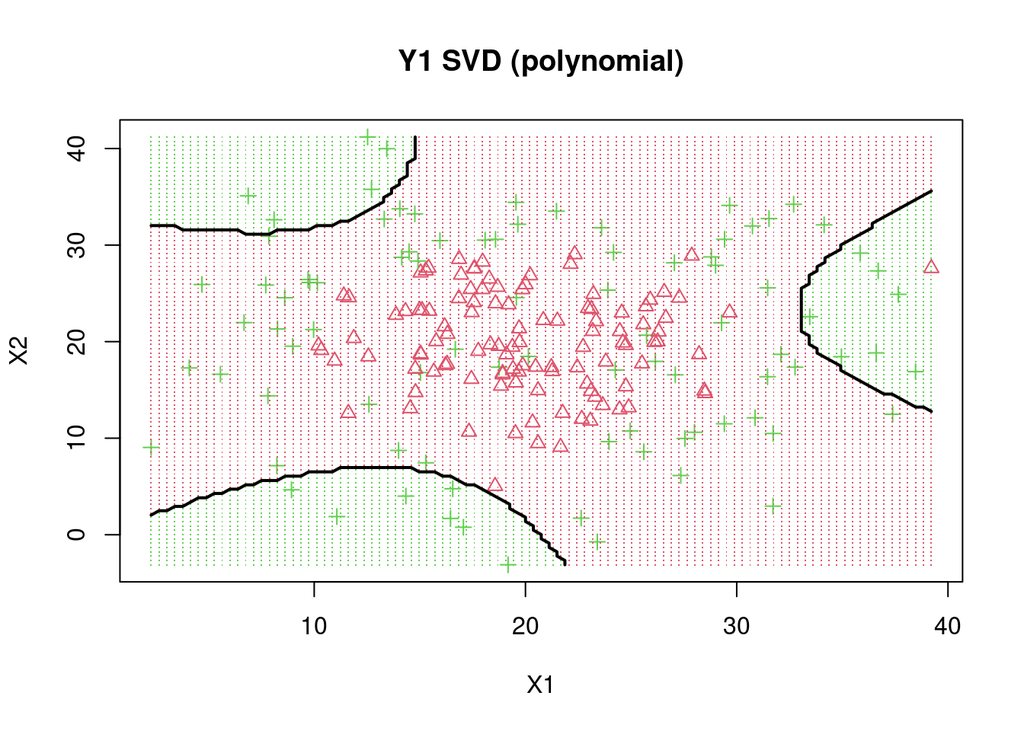

```r
# polynomial kernel

svm.model2 <- svm(Y1 ~ ., data[,-4], kernel = "polynomial")
boundary(svm.model2, data[,-4], class = "Y1", main = "Y1 SVD (polynomial)")
```

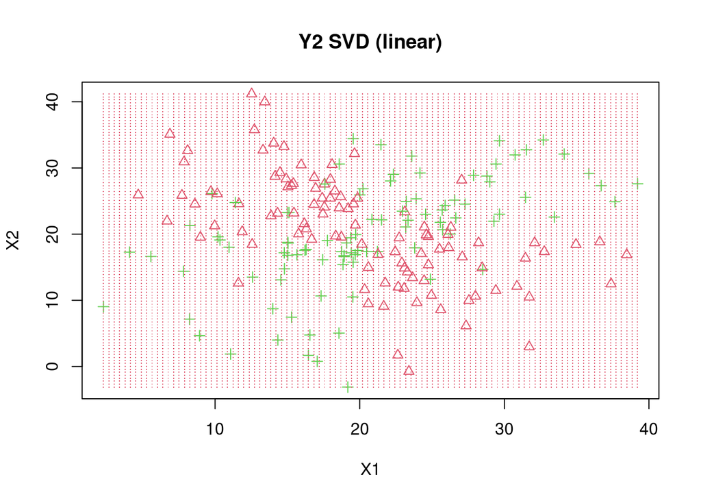

```r
# Y2
svm.model3 <- svm(Y2 ~ ., data[,-3], kernel="linear")
boundary(svm.model3, data[,-3], class = "Y2", main = "Y2 SVD (linear)")
```

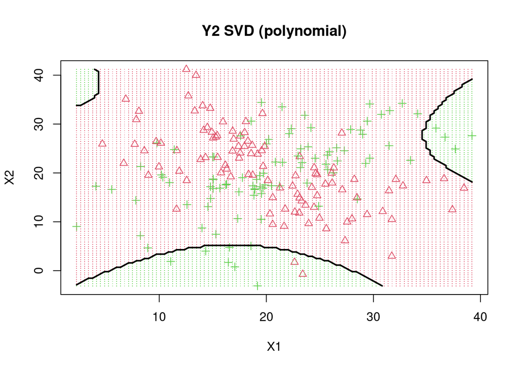

```r
svm.model4 <- svm(Y2 ~ ., data[,-3], kernel = "polynomial")
boundary(svm.model4, data[,-3], class = "Y2", main = "Y2 SVD (polynomial)")
```

The SVM linear boundary for Y1 is shown in graph. That is because the decision value for A/B is almost 1, the whole dataset is classfied as red points which is absolutely wrong. The SVM polynomial boundary for Y1 is shown with curves with three regions identified as green points. However, it is still different as the actual bounday especially when X1 and X2 are less than 20 or greater than 30, the sum of sqaure will be larger than 100. There are lots of green points in the middle are misclassified and this method is not accurate.

The SVM linear boundary for Y2 is shown in graph. That is because the decision value for A/B is almost 1, the whole dataset is classfied as red points which is absolutely wrong. The SVM polynomial boundary for Y2 is shown with curves with three regions identified as green points. However, it is still different as the actual bounday especially when X2 is smaller than 20, X1 should be greater than 20, the boundary include X1 from 0 to 30 which is not the same as actual boundary. There are lots of green points in the middle are misclassified and this method is not accurate.

# Conclusion

However, for the last three model, knn, bagging and random forest, since there are only two classes, bagging and random forest are almost the same model. The knn seems identifies all the boundary which is the same as actual, though it does not handle the outliers. The boundary for knn is easiest to describe. For bagging or random forest, the boundary is also quite good and it is the same as the actual. There are even classification for some outliers which seems out of range. Like in Y1 X1 is greater than 30 for red points. That might seems not right as (X1-20)^2 > 100, that is to say, there might be the overfitting problem for random forest or bagging especially when the sample is small.